# Lab 8

Sarah Roffo

Complete the following exercises in Chapter 8 (Introduction to Regression Analysis) of the textbook [R] pages 247-250.

## Question 1

This is Exercise 1 in Chapter 8 of the Textbook [R].

A regression of weekly shopping trip frequency on annual income (data entered in thousands of dollars) is performed on data collected from 24 respondents. The results are summarized below:

- Intercept: 0.46
- Slope: 0.19

|  | Sum of squares | Degrees of freedom | Mean square | *F* |
| --- | --- | --- | --- | --- |
| Regression |  |  |  |  |
| Residual | 1.7 |  |  |  |
| Total | 2.3 |  |  |  |

### Question 1(a)

Fill in the blanks in the ANOVA table.

```r
N <- 24
x <- 2.3 - 1.7
```

|  | Sum of squares | Degrees of freedom | Mean square | *F* |
| --- | --- | --- | --- | --- |
| Regression | 0.6 | 1 | 0.6 | 7.7647059 |
| Residual | 1.7 | 22 | 0.0772727 |  |
| Total | 2.3 | 23 |  |  |

### Question 1(b)

What is the predicted number of weekly shopping trips for someone making $50,000/year?

```r
trips <- ((0.19 * 50) + 0.46)
trips
```

```
[1] 9.96
```

```r
print('The predicted number of weekly shopping trips for someone making $50,000/year is 9.96 trips.')
```

```
[1] "The predicted number of weekly shopping trips for someone making $50,000/year is 9.96 trips."
```

### Question 1(c)

In words, what is the meaning of the coefficient 0.19?

```r
print('Every additional $1,000 in annual income increases the chances of a weekly shopping trip by 0.19.')
```

```
[1] "Every additional $1,000 in annual income increases the chances of a weekly shopping trip by 0.19."
```

### Question 1(d)

Is the regression coefficient significantly different from zero? How do you know?

```r
f <- x/(1.7/(24 - 2))
qf(0.95, 1, 22)
```

```
[1] 4.30095
```

```r
print('Yes, the regression coefficient is significantly different from 0. I know this from comparing the F value to f critical.')
```

```
[1] "Yes, the regression coefficient is significantly different from 0. I know this from comparing the F value to f critical."
```

### Question 1(e)

What is the value of the correlation coefficient?

```r
correlation_coefficient <- sqrt((2.3 - 1.7)/2.3)
correlation_coefficient
```

```
[1] 0.5107539
```

## Question 2

This is Exercise 6 in Chapter 8 of the Textbook [R].

The following data are collected in an effort to determine whether snowfall is dependent upon elevation:

| Snowfall (inches) | Elevation (feet) |
| --- | --- |
| 36 | 400 |
| 78 | 800 |
| 11 | 200 |
| 45 | 675 |

Using R, show your work on exercises (a) through (g).

### Question 2(a)

Find the regression coefficients (the intercept and the slope coefficient).

```r
snowfall <- c(36, 78, 11, 45)
elevation <- c(400, 800, 200, 675)
df <- data.frame(snowfall, elevation)
m <- lm(snowfall ~ elevation, data = df)
summary(m)
```

```
Call:
lm(formula = snowfall ~ elevation, data = df)

Residuals:
       1        2        3        4
  4.9772   8.3172  -0.6928 -12.6016

Coefficients:
            Estimate Std. Error t value Pr(>|t|)
(Intercept) -7.63721   13.67764  -0.558   0.6328
elevation    0.09665    0.02403   4.022   0.0566 .
---
Signif. codes:  0 ‘***’ 0.001 ‘**’ 0.01 ‘*’ 0.05 ‘.’ 0.1 ‘ ’ 1

Residual standard error: 11.25 on 2 degrees of freedom
Multiple R-squared:  0.8899,    Adjusted R-squared:  0.8349
F-statistic: 16.17 on 1 and 2 DF,  p-value: 0.05663
```

```r
m$coefficients
```

```
(Intercept)   elevation
-7.63720599  0.09665004
```

```r
#intercept = -7.63720599
#slope coefficient = 0.09665004
```

### Question 2(b)

Estimate the standard error of the residuals about the regression line.

```r
summary(m)
```

```
Call:
lm(formula = snowfall ~ elevation, data = df)

Residuals:
       1        2        3        4
  4.9772   8.3172  -0.6928 -12.6016

Coefficients:
            Estimate Std. Error t value Pr(>|t|)
(Intercept) -7.63721   13.67764  -0.558   0.6328
elevation    0.09665    0.02403   4.022   0.0566 .
---
Signif. codes:  0 ‘***’ 0.001 ‘**’ 0.01 ‘*’ 0.05 ‘.’ 0.1 ‘ ’ 1

Residual standard error: 11.25 on 2 degrees of freedom
Multiple R-squared:  0.8899,    Adjusted R-squared:  0.8349
F-statistic: 16.17 on 1 and 2 DF,  p-value: 0.05663
```

```r
#Residual standard error = 11.25
```

### Question 2(c)

Test the hypothesis that the regression coefficient associated with the independent variables is equal to zero. Also place a 95% confidence interval on the regression coefficient.

```r
conf <- qf(0.95, 1, 2)
conf
```

```
[1] 18.51282
```

```r
print('We accept the null hypothesis that the regression coefficient associated with the independent variables is equal to zero.')
```

```
[1] "We accept the null hypothesis that the regression coefficient associated with the independent variables is equal to zero."
```

### Question 2(d)

Find the value of $r^2$.

```r
(cor(snowfall, elevation))^2
```

```
[1] 0.889949
```

### Question 2(e)

Make a table of the observed values, predicted values, and the residuals.

```r
library(knitr)
df$Predicted_Values <- m$fitted.values
df$Residuals <- m$residuals
kable(df)
```

| snowfall | elevation | Predicted_Values | Residuals |
| --- | --- | --- | --- |
| 36 | 400 | 31.02281 | 4.9771917 |
| 78 | 800 | 69.68282 | 8.3171775 |
| 11 | 200 | 11.69280 | -0.6928011 |
| 45 | 675 | 57.60157 | -12.6015681 |

### Question 2(f)

Prepare an analysis of variance table portraying the regression results.

```r
anova(m)
```

```
Analysis of Variance Table

Response: snowfall
          Df  Sum Sq Mean Sq F value  Pr(>F)
elevation  1 2047.77 2047.77  16.173 0.05663 .
Residuals  2  253.23  126.61
---
Signif. codes:  0 ‘***’ 0.001 ‘**’ 0.01 ‘*’ 0.05 ‘.’ 0.1 ‘ ’ 1
```

|  | Sum of squares | Degrees of freedom | Mean square | *F* |
| --- | --- | --- | --- | --- |
| Regression | 2047.77 | 1 | 2047.77 | 16.173 |
| Residual | 253.23 | 2 | 126.61 |  |
| Total | 2301 | 3 |  |  |

### Question 2(g)

Graph the data and the regression line.

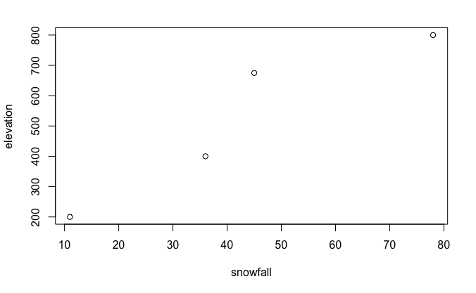

```r
df <- data.frame(snowfall, elevation)
plot(snowfall, elevation)
m <- lm(snowfall ~ elevation, data= df)
abline(m, col = "blue")
```

## Question 3

This is Exercise 10 in Chapter 8 of the Textbook [R].

Use R and the [Milwaukee dataset](http://spatial.binghamton.edu/geog533/data/Milwaukee_Sales.csv) to:

### Problem

perform a regression using sales price as the dependent variable and lot size as the independent variable.

### Solution

```r
url = "http://spatial.binghamton.edu/geog533/data/Milwaukee_Sales.csv"
Milwaukee_Sales <- read.csv(url)
price <- Milwaukee_Sales$SalePrice
lot <- Milwaukee_Sales$LotSize
df <- data.frame(price, lot)
m <- lm(price ~ lot, data = df)
summary(m)
```

```
Call:
lm(formula = price ~ lot, data = df)

Residuals:
    Min      1Q  Median      3Q     Max
-144724  -42205  -14553   20987  808570

Coefficients:
             Estimate Std. Error t value Pr(>|t|)
(Intercept) 9.298e+04  5.249e+03  17.715  < 2e-16 ***
lot         6.443e+00  7.835e-01   8.223 4.37e-16 ***
---
Signif. codes:  0 ‘***’ 0.001 ‘**’ 0.01 ‘*’ 0.05 ‘.’ 0.1 ‘ ’ 1

Residual standard error: 83090 on 1447 degrees of freedom
Multiple R-squared:  0.04464,   Adjusted R-squared:  0.04398
F-statistic: 67.62 on 1 and 1447 DF,  p-value: 4.374e-16
```

## Question 4

This is Exercise 11 in Chapter 8 of the Textbook [R].

Use R and the Hypothetical [UK Housing Prices dataset](http://spatial.binghamton.edu/geog533/data/UK_Housing.csv) to:

### Question 4(a)

perform a regression using house price as the dependent variable, and number of bedrooms as the independent variable;

```r
url = "http://spatial.binghamton.edu/geog533/data/UK_Housing.csv"
UK_Housing <- read.csv(url)
price <- UK_Housing$price
bedrooms <- UK_Housing$bedrooms
df <- data.frame(price, bedrooms)
m <- lm(price ~ bedrooms, data = df)
summary(m)
```

```
Call:
lm(formula = price ~ bedrooms, data = df)

Residuals:
   Min     1Q Median     3Q    Max
-39324 -11511  -3539   8461 107568

Coefficients:
            Estimate Std. Error t value Pr(>|t|)
(Intercept)  11254.1     2312.7   4.866 1.53e-06 ***
bedrooms     11892.6      876.5  13.568  < 2e-16 ***
---
Signif. codes:  0 ‘***’ 0.001 ‘**’ 0.01 ‘*’ 0.05 ‘.’ 0.1 ‘ ’ 1

Residual standard error: 17800 on 497 degrees of freedom
Multiple R-squared:  0.2703,    Adjusted R-squared:  0.2688
F-statistic: 184.1 on 1 and 497 DF,  p-value: < 2.2e-16
```

### Question 4(b)

2. repeat part (a), using the number of bathrooms as the independent variable, and comment on the results.

```r
price <- UK_Housing$price
bathrooms <- UK_Housing$bathrooms
df <- data.frame(price, bathrooms)
m <- lm(price ~ bathrooms, data = df)
summary(m)
```

```
Call:
lm(formula = price ~ bathrooms, data = df)

Residuals:
   Min     1Q Median     3Q    Max
-34955 -15242  -5342  10908 114658

Coefficients:
            Estimate Std. Error t value Pr(>|t|)
(Intercept)    32729       3149  10.394  < 2e-16 ***
bathrooms       7113       2682   2.653  0.00824 **
---
Signif. codes:  0 ‘***’ 0.001 ‘**’ 0.01 ‘*’ 0.05 ‘.’ 0.1 ‘ ’ 1

Residual standard error: 20690 on 497 degrees of freedom
Multiple R-squared:  0.01396,   Adjusted R-squared:  0.01198
F-statistic: 7.036 on 1 and 497 DF,  p-value: 0.008245
```

```r
print('The results show that the price of a home is related to the number of bathrooms in it.')
```

```
[1] "The results show that the price of a home is related to the number of bathrooms in it."
```

## Question 5

Download the hometown.csv, append your name and hometown coordinates to the csv, then use [leaflet](https://rstudio.github.io/leaflet/) to create a web map (10 pt.)

```r
library(leaflet)
hometown <- read.csv("hometown.csv")
m <- leaflet(data = hometown)
m <- addTiles(m)
m <- addMarkers(m, ~longitude, ~ latitude, popup = ~ as.character(fullname), clusterOptions = markerClusterOptions())
m
```

[interactive chart not shown]